# final_stat

Enjung Hong

2023-12-16

1. 데이터 설명
- name: 축구 선수의 이름.
- club: 선수가 속한 클럽.
- age: 선수의 나이.
- position: 선수의 일반적인 풀이 위치.
- position_cat: 선수 위치의 범주화 (1은 공격수, 2는 중앙미드필더, 3은 수비수, 4는 골키퍼).
- market_value: 2017년 7월 20일 기준으로 선수의 이적 시장 가치.
- page_views: 2016년 9월 1일부터 2017년 5월 1일까지의 평균 일일 위키백과 페이지 조회수로, 선수의 인기를 나타냅니다.
- fpl_value: 2017년 7월 20일 기준으로 판타지 프리미어 리그에서의 선수 가치.
- fpl_sel: 판타지 프리미어 리그 선수 중 해당 선수를 선택한 선수의 백분율.
- fpl_points: 이전 시즌 동안 선수가 획득한 판타지 프리미어 리그 포인트.
- region: 선수의 지역을 나타내는 범주화 (1은 잉글랜드, 2는 EU, 3은 아메리카, 4는 기타 지역).
- nationality: 선수의 국적.
- new_foreign: 2017/18 시즌에 다른 리그에서 온 신규 선수인지 여부를 나타냅니다 (7월 20일까지).
- age_cat: 선수의 연령을 범주화한 것.
- club_id: 클럽 식별용.
- big_club: 선수가 Top 6 클럽 중 하나에 속하는지 여부를 나타냅니다.
- new_signing: 2017/18 시즌에 신규 선수로 등록되었는지 여부를 나타냅니다 (7월 20일까지).

이 데이터셋은 선수의 속성, 인기, 그리고 시장 가치 간의 관계를 탐구하고, 축구를 통계적으로 분석하는 것을 목표로 하는 것으로 보입니다. 선수의 시장 가치에 영향을 미치는 요소에 대한 통찰을 얻을 수 있는 양적 및 범주적 변수의 흥미로운 조합입니다.

```r
library(dplyr)
```

```r
library(ggcorrplot)
library(ggplot2)
# 데이터 불러오기
epl_Data <- read.csv("/Users/enjunghong/Downloads/epldata_final.csv")
#View(epl_Data)
rownames(epl_Data) <- epl_Data$name
epl_Data <- epl_Data[, -1, drop = FALSE]

# 데이터 살펴보기
str(epl_Data)
```

```
## 'data.frame':    461 obs. of  16 variables:
##  $ club        : chr  "Arsenal" "Arsenal" "Arsenal" "Arsenal" ...
##  $ age         : int  28 28 35 28 31 22 30 31 25 21 ...
##  $ position    : chr  "LW" "AM" "GK" "RW" ...
##  $ position_cat: int  1 1 4 1 3 3 1 3 3 1 ...
##  $ market_value: num  65 50 7 20 22 30 22 13 30 10 ...
##  $ page_views  : int  4329 4395 1529 2393 912 1675 2230 555 1877 1812 ...
##  $ fpl_value   : num  12 9.5 5.5 7.5 6 6 8.5 5.5 5.5 5.5 ...
##  $ fpl_sel     : chr  "17.10%" "5.60%" "5.90%" "1.50%" ...
##  $ fpl_points  : int  264 167 134 122 121 119 116 115 90 89 ...
##  $ region      : int  3 2 2 1 2 2 2 2 2 4 ...
##  $ nationality : chr  "Chile" "Germany" "Czech Republic" "England" ...
##  $ new_foreign : int  0 0 0 0 0 0 0 0 0 0 ...
##  $ age_cat     : int  4 4 6 4 4 2 4 4 3 1 ...
##  $ club_id     : int  1 1 1 1 1 1 1 1 1 1 ...
##  $ big_club    : int  1 1 1 1 1 1 1 1 1 1 ...
##  $ new_signing : int  0 0 0 0 0 0 0 0 1 0 ...
```

```r
dim(epl_Data)
```

```
## [1] 461  16
```

```r
names(epl_Data)
```

```
##  [1] "club"         "age"          "position"     "position_cat" "market_value"
##  [6] "page_views"   "fpl_value"    "fpl_sel"      "fpl_points"   "region"
## [11] "nationality"  "new_foreign"  "age_cat"      "club_id"      "big_club"
## [16] "new_signing"
```

```r
table(epl_Data$club)
```

```
##
##           Arsenal       Bournemouth Brighton+and+Hove           Burnley
##                28                24                22                18
##           Chelsea    Crystal+Palace           Everton      Huddersfield
##                20                21                28                28
##    Leicester+City         Liverpool   Manchester+City Manchester+United
##                24                27                20                25
##  Newcastle+United       Southampton        Stoke+City           Swansea
##                21                23                22                25
##         Tottenham           Watford         West+Brom          West+Ham
##                20                24                19                22
```

```r
table(epl_Data$age)
```

```
##
## 17 18 19 20 21 22 23 24 25 26 27 28 29 30 31 32 33 34 35 36 37 38
##  1  3  8 13 25 19 24 33 42 50 58 39 30 35 22 23  9 13  6  5  2  1
```

```r
table(epl_Data$position)
```

```
##
## AM CB CF CM DM GK LB LM LW RB RM RW SS
## 17 85 61 63 36 42 35  8 36 34  5 32  7
```

```r
table(epl_Data$market_value)
```

```
##
## 0.05  0.1 0.25  0.5 0.65 0.75    1 1.25  1.5 1.75    2  2.5    3  3.5    4  4.5
##    1    1   11   14    1    6   21    1   21    1   17   17   16   11   15    8
##    5  5.5    6    7  7.5    8    9   10   11   12   13   14   15   16   17   18
##   41    5   20   22    1   22   12   23    3   16    5    2   28    2    4   14
##   20   21   22   24   25   28   30   32   35   38   40   45   50   60   65   75
##    6    1    8    1   11    6   16    1    9    1    6    3    4    1    3    2
```

```r
table(epl_Data$region)
```

```
##
##   1   2   3   4
## 156 207  41  56
```

```r
table(epl_Data$nationality)
```

```
##
##             Algeria           Argentina             Armenia           Australia
##                   3                  17                   1                   4
##             Austria             Belgium               Benin             Bermuda
##                   4                  18                   1                   1
##              Bosnia              Brazil            Cameroon              Canada
##                   2                  12                   3                   1
##               Chile            Colombia            Congo DR       Cote d'Ivoire
##                   2                   1                   4                   4
##             Croatia             Curacao      Czech Republic             Denmark
##                   1                   1                   2                   6
##             Ecuador               Egypt             England             Estonia
##                   2                   4                 156                   1
##             Finland              France             Germany               Ghana
##                   1                  25                  16                   5
##              Greece             Iceland             Ireland              Israel
##                   1                   2                  17                   2
##               Italy             Jamaica               Japan               Kenya
##                   4                   2                   2                   1
##                Mali             Morocco         Netherlands         New Zealand
##                   2                   2                  20                   1
##             Nigeria    Northern Ireland              Norway              Poland
##                   6                   6                   1                   3
##            Portugal             Romania            Scotland             Senegal
##                   6                   1                  14                   7
##              Serbia            Slovenia         South Korea               Spain
##                   5                   1                   3                  28
##              Sweden         Switzerland          The Gambia Trinidad and Tobago
##                   3                   4                   1                   1
##             Tunisia       United States             Uruguay           Venezuela
##                   1                   2                   1                   1
##               Wales
##                  12
```

```r
table(epl_Data$big_club)
```

```
##
##   0   1
## 321 140
```

2. 데이터 전처리

```r
# 선택에 제외할 변수들 지정
no_sel_var <- c("club", "position", "fpl_sel", "nationality","age_cat","club_id","new_foreign","page_views","name")

selected_data <- epl_Data[, !(names(epl_Data) %in% no_sel_var)]
names(selected_data)
```

```
## [1] "age"          "position_cat" "market_value" "fpl_value"    "fpl_points"
## [6] "region"       "big_club"     "new_signing"
```

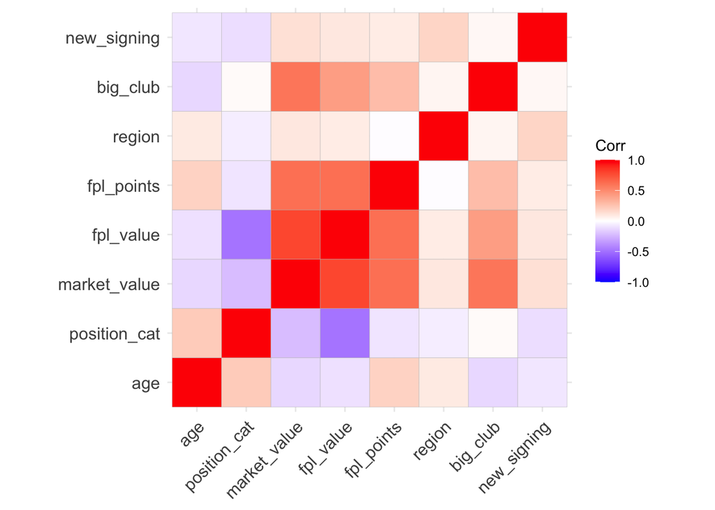

```r
# 결측치 제거
selected_data <- na.omit(selected_data)

standardized_data <- scale(selected_data)

cor_matrix <- cor(standardized_data)
ggcorrplot(cor_matrix)
```

3. PCA

```r
pr.out = prcomp(standardized_data, scale=T)
names(pr.out)
```

```
## [1] "sdev"     "rotation" "center"   "scale"    "x"
```

```r
pr.out$scale
```

```
##          age position_cat market_value    fpl_value   fpl_points       region
##            1            1            1            1            1            1
##     big_club  new_signing
##            1            1
```

```r
pr.out$rotation
```

```
##                      PC1         PC2          PC3        PC4         PC5
## age          -0.08084312  0.64882372 -0.375175218 -0.3741868  0.02621856
## position_cat -0.24567470  0.55652575  0.009940599  0.5622762  0.13530351
## market_value  0.54348759  0.07873036  0.050753425  0.1326881 -0.02814093
## fpl_value     0.54280208 -0.05167855  0.032818151 -0.2247564 -0.05488560
## fpl_points    0.42937435  0.37384389 -0.052005202 -0.2304335  0.24792087
## region        0.07660308 -0.08718619 -0.721020545  0.1695439 -0.61696428
## big_club      0.37223816  0.15175345  0.186879615  0.5712766 -0.17138081
## new_signing   0.11959879 -0.30007987 -0.545887023  0.2598200  0.71114003
##                      PC6         PC7         PC8
## age          -0.51214381  0.16052355 -0.05452927
## position_cat  0.38788561  0.26802074  0.27031882
## market_value  0.11090382  0.53179493 -0.61833916
## fpl_value     0.01690694  0.34496316  0.72718975
## fpl_points    0.44604865 -0.59536606 -0.07203749
## region        0.21775916 -0.09789121  0.01637457
## big_club     -0.55321784 -0.36870920  0.07590004
## new_signing  -0.14912927  0.02453030  0.03984607
```

```r
dim(pr.out$x)
```

```
## [1] 460   8
```

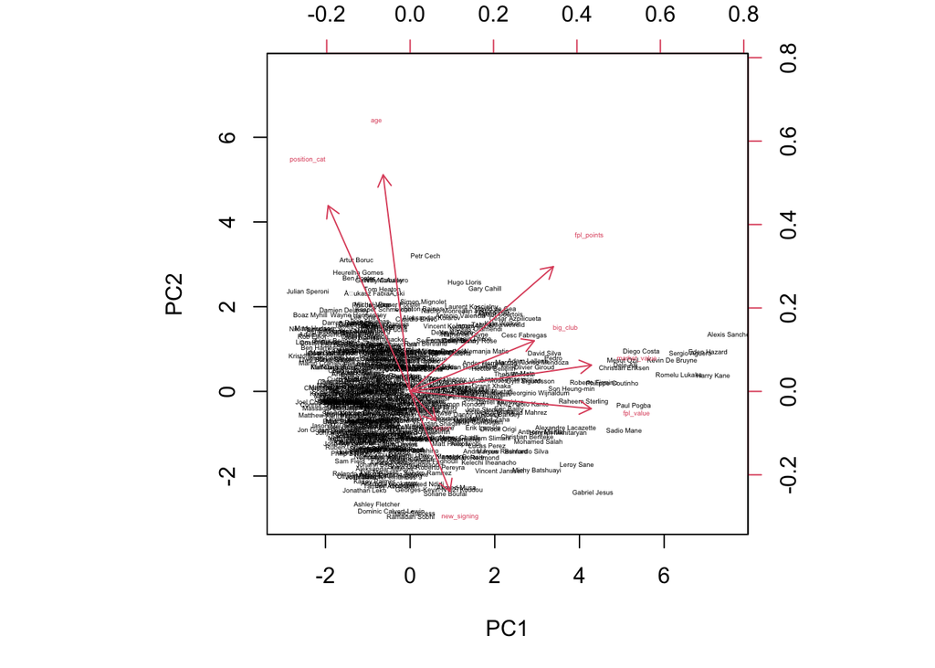

```r
par(mfrow=c(1,1), mar=c(5,5,2,2))
biplot(pr.out, scale = 0, cex = 0.3)
```

```r
# biplot에서 변수들의 화살표와 데이터의 분포를 좀 더 쉽게 해석
pr.out$rotation = -pr.out$rotation
pr.out$x = -pr.out$x
summary(pr.out)
```

```
## Importance of components:
##                           PC1    PC2    PC3    PC4    PC5     PC6     PC7
## Standard deviation     1.6860 1.1321 1.0762 0.9920 0.9120 0.71382 0.49867
## Proportion of Variance 0.3553 0.1602 0.1448 0.1230 0.1040 0.06369 0.03108
## Cumulative Proportion  0.3553 0.5156 0.6603 0.7833 0.8873 0.95099 0.98208
##                            PC8
## Standard deviation     0.37866
## Proportion of Variance 0.01792
## Cumulative Proportion  1.00000
```

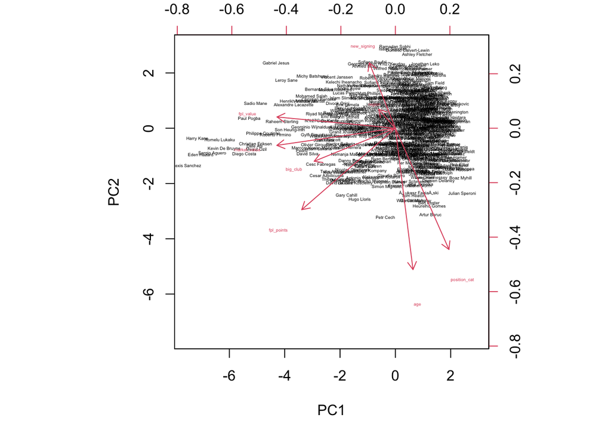

```r
par(mfrow=c(1,1), mar=c(5,5,2,2))
biplot(pr.out, scale = 0, cex = 0.3)
```

```r
pr.out$sdev
```

```
## [1] 1.6860338 1.1321383 1.0761638 0.9919703 0.9120444 0.7138244 0.4986674
## [8] 0.3786550
```

```r
pr.var = pr.out$sdev^2
pr.var
```

```
## [1] 2.8427099 1.2817372 1.1581285 0.9840052 0.8318250 0.5095453 0.2486692
## [8] 0.1433796
```

```r
pve = pr.var/sum(pr.var)
pve
```

```
## [1] 0.35533874 0.16021715 0.14476607 0.12300065 0.10397813 0.06369316 0.03108365
## [8] 0.01792246
```

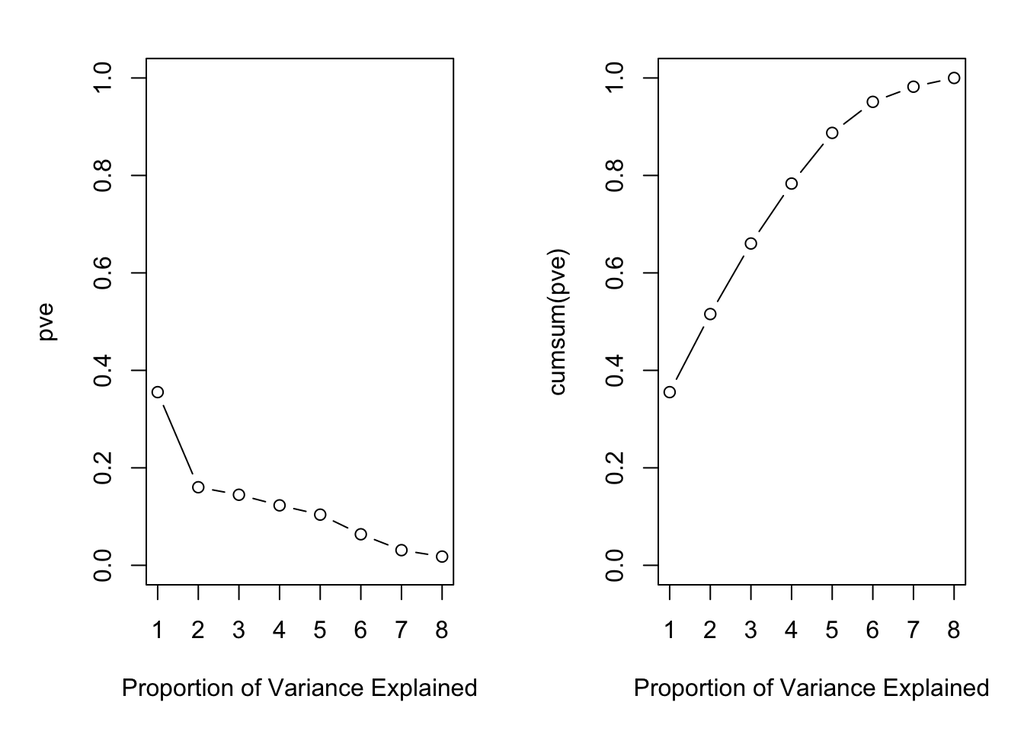

```r
par(mfrow = c(1,2))
plot(pve, xlab="Proportion of Variance Explained", ylim=c(0,1), type="b")
plot(cumsum(pve), xlab="Proportion of Variance Explained", ylim=c(0,1), type="b")
```

4.Clustering

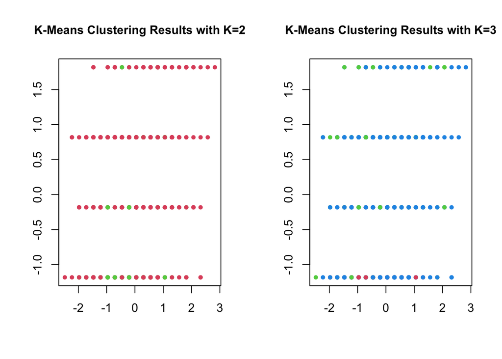

```r
# K-means 클러스터링 수행
x=standardized_data
par(mfrow = c(1,2))
k <- 2  # 클러스터 수
kmeans_result <- kmeans(x, centers = k)
cluster_assignments <- kmeans_result$cluster

plot(x, col=(kmeans_result$cluster+1),
     main="K-Means Clustering Results with K=2",
     xlab="",ylab="", pch=20, cex=1, cex.main=1)

k <- 3  # 클러스터 수
kmeans_result <- kmeans(standardized_data, centers = k)
cluster_assignments <- kmeans_result$cluster

plot(x, col=(kmeans_result$cluster+1),
     main="K-Means Clustering Results with K=3",
     xlab="",ylab="", pch=20, cex=1, cex.main=1)
```

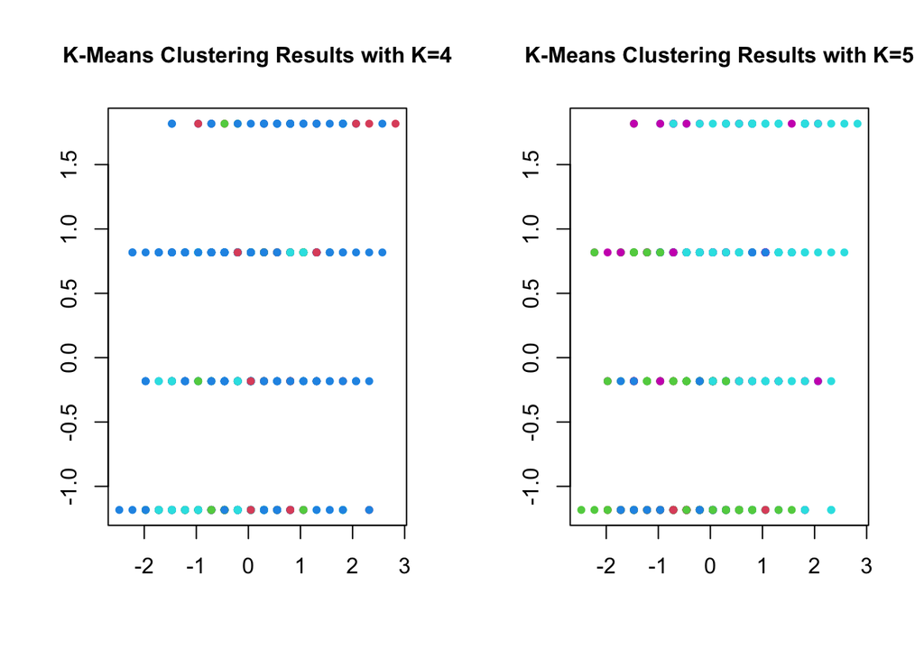

```r
k <- 4  # 클러스터 수
kmeans_result <- kmeans(standardized_data, centers = k)
cluster_assignments <- kmeans_result$cluster

plot(x, col=(kmeans_result$cluster+1),
     main="K-Means Clustering Results with K=4",
     xlab="",ylab="", pch=20, cex=1, cex.main=1)

k <- 5  # 클러스터 수
kmeans_result <- kmeans(standardized_data, centers = k)
cluster_assignments <- kmeans_result$cluster

plot(x, col=(kmeans_result$cluster+1),
     main="K-Means Clustering Results with K=5",
     xlab="",ylab="", pch=20, cex=1, cex.main=1)
```

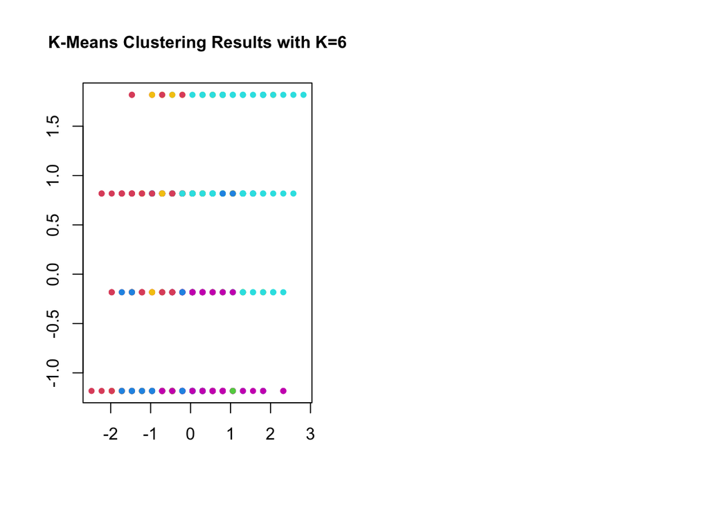

```r
k <- 6  # 클러스터 수
kmeans_result <- kmeans(standardized_data, centers = k)
cluster_assignments <- kmeans_result$cluster

plot(x, col=(kmeans_result$cluster+1),
     main="K-Means Clustering Results with K=6",
     xlab="",ylab="", pch=20, cex=1, cex.main=1)
```

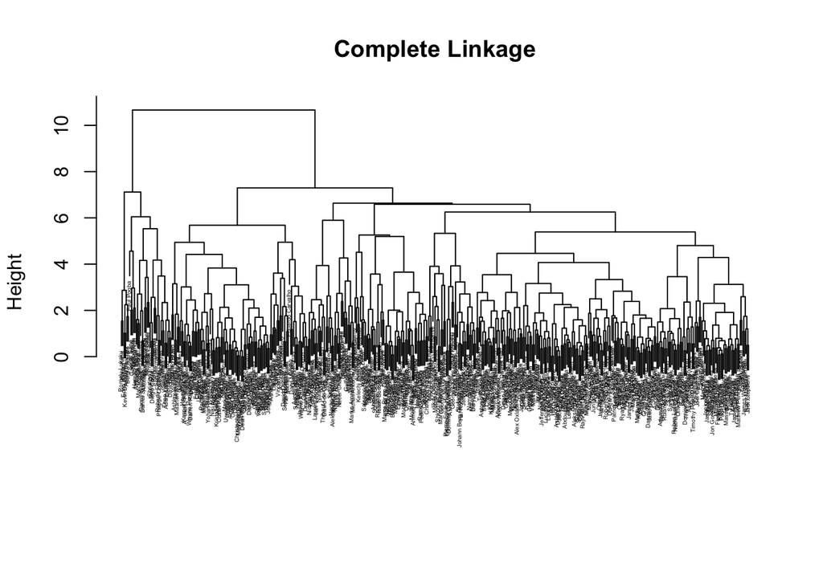

```r
# x를 사용하여 최장 연결 방법으로 계산된 계층적 클러스터링 결과
hc.complete = hclust(dist(standardized_data), method="complete")
# x를 사용하여 평균 연결 방법으로 계산된 계층적 클러스터링 결과
hc.average = hclust(dist(standardized_data), method="average")
# x를 사용하여 최소 연결 방법으로 계산된 계층적 클러스터링 결과
hc.single = hclust(dist(standardized_data), method="single")


plot(hc.complete, main="Complete Linkage", xlab="", sub="", cex=0.3)
```

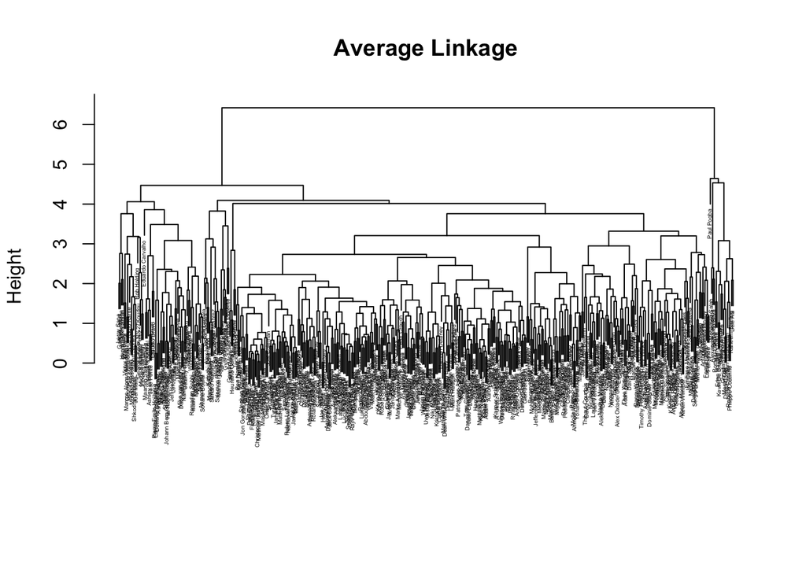

```r
plot(hc.average, main="Average Linkage", xlab="", sub="", cex=0.3)
```

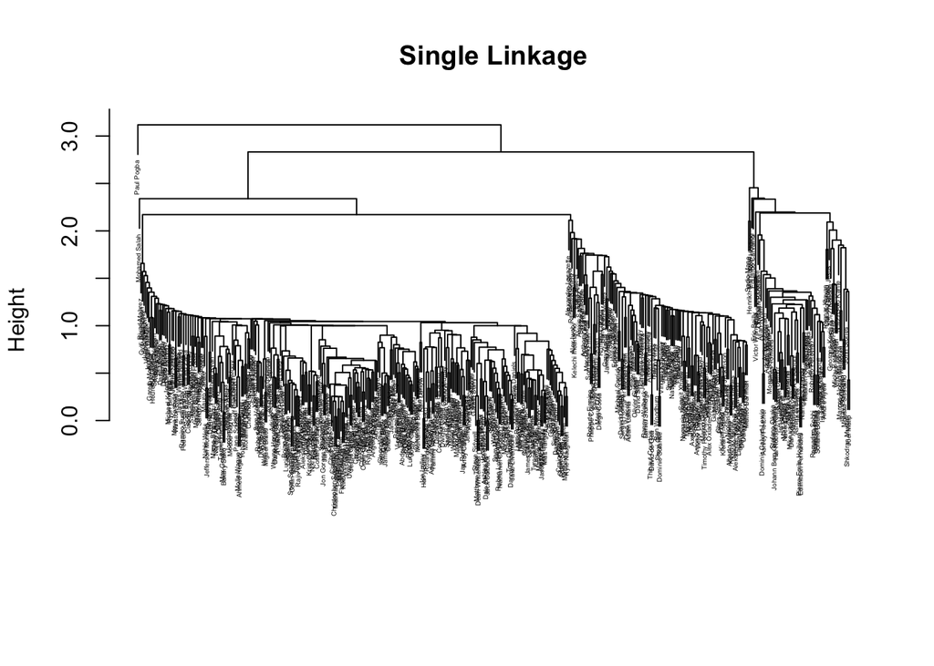

```r
plot(hc.single, main="Single Linkage", xlab="", sub="", cex=0.3)
```

```r
# cutree: 계층적 클러스터링 결과에서 지정된 수의 클러스터로 자르는 데 사용
# cutree(hc.complete,2)
#cutree(hc.average,2)
#cutree(hc.single,2)
#cutree(hc.single,4)
```

전체를 보았을때 차이를 느끼지 못해 상위 클럽 2곳과 하위 클럽 2곳을 비교하여 특성을 파악하고자 한다.

- 맨시티, 맨유, 스토크시티, 웨스트브롬

```r
#unique(epl_Data$club)
selected_clubs <- c("Manchester+City", "Manchester+United", "Stoke+City","West+Brom")

ManCity <- epl_Data[epl_Data$club == selected_clubs[1],c("age","position_cat","market_value", "fpl_value", "fpl_points", "region","new_signing")]
ManUnited <- epl_Data[epl_Data$club == selected_clubs[2],c("age","position_cat","market_value", "fpl_value", "fpl_points", "region","new_signing")]
Stoke <- epl_Data[epl_Data$club == selected_clubs[3],c("age","position_cat","market_value", "fpl_value", "fpl_points", "region","new_signing")]
West <- epl_Data[epl_Data$club == selected_clubs[4],c("age","position_cat","market_value", "fpl_value", "fpl_points", "region","new_signing")]
```

```r
par(mfrow = c(1,2))
ManCity_s = data.matrix(scale(ManCity))
ManCity_pr = prcomp(ManCity_s, scale=T)
ManCity_pr$rotation
```

```
##                       PC1         PC2         PC3        PC4         PC5
## age           0.285740207  0.60121745 -0.18692540 0.35011980 -0.38474128
## position_cat  0.443509424 -0.01518135 -0.34592520 0.27896050  0.73517193
## market_value -0.517316051  0.02923486 -0.19027406 0.04338892  0.39883807
## fpl_value    -0.535811546  0.06044316  0.21115997 0.15755537  0.10463240
## fpl_points   -0.392249261  0.40105110 -0.32983747 0.36949786 -0.02956513
## region        0.114238253  0.31779659  0.80879719 0.28244965  0.29181860
## new_signing  -0.005670476 -0.60988720  0.04069711 0.74604584 -0.23546643
##                      PC6         PC7
## age           0.47224589  0.16829467
## position_cat -0.08015089  0.24224734
## market_value  0.62711043 -0.37563721
## fpl_value     0.01671820  0.79285115
## fpl_points   -0.60755996 -0.26452582
## region       -0.03387139 -0.25635696
## new_signing   0.08207495 -0.08708653
```

```r
summary(ManCity_pr)
```

```
## Importance of components:
##                           PC1    PC2    PC3    PC4    PC5    PC6     PC7
## Standard deviation     1.7189 1.1877 1.0436 0.8979 0.6339 0.4696 0.34210
## Proportion of Variance 0.4221 0.2015 0.1556 0.1152 0.0574 0.0315 0.01672
## Cumulative Proportion  0.4221 0.6236 0.7792 0.8944 0.9518 0.9833 1.00000
```

```r
biplot(ManCity_pr, scale = 0, cex = 0.5, main = "ManCity",cex.main=1)


ManUnited_s = data.matrix(scale(ManUnited))
ManUnited_pr = prcomp(ManUnited_s, scale=T)
ManUnited_pr$rotation
```

```
##                      PC1         PC2         PC3         PC4        PC5
## age           0.02362735 -0.23336812  0.90279347  0.19237054 -0.2771747
## position_cat  0.29846231 -0.48026322 -0.06486985 -0.71293343 -0.1480327
## market_value -0.49714072 -0.01046209 -0.11425111 -0.25198458 -0.5092737
## fpl_value    -0.51193520  0.24803536  0.06397138 -0.03304403  0.2471794
## fpl_points   -0.46565364  0.12015628  0.27022146 -0.47739542  0.1229221
## region       -0.25381679 -0.64750465  0.01670423  0.07606240  0.6312906
## new_signing  -0.34623573 -0.46856777 -0.30051876  0.39552431 -0.4088588
##                      PC6        PC7
## age           0.10140816 -0.0763490
## position_cat  0.06755042 -0.3759103
## market_value  0.50126644  0.4068960
## fpl_value     0.32362112 -0.7109067
## fpl_points   -0.65095100  0.1701648
## region        0.20201819  0.2662913
## new_signing  -0.40571677 -0.2864306
```

```r
summary(ManUnited_pr)
```

```
## Importance of components:
##                           PC1    PC2    PC3    PC4     PC5     PC6     PC7
## Standard deviation     1.7673 1.1910 1.0250 0.8486 0.68676 0.34907 0.30674
## Proportion of Variance 0.4462 0.2026 0.1501 0.1029 0.06738 0.01741 0.01344
## Cumulative Proportion  0.4462 0.6488 0.7989 0.9018 0.96915 0.98656 1.00000
```

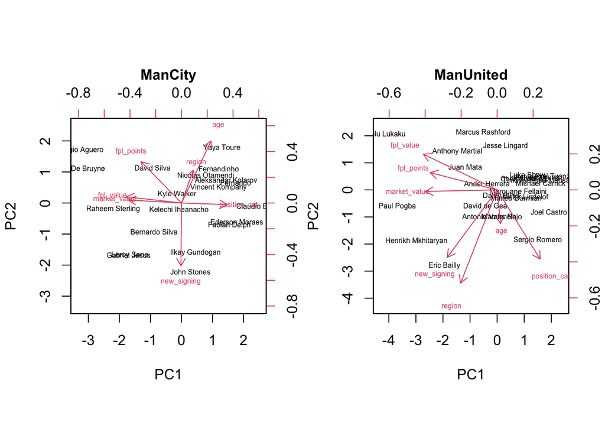

```r
biplot(ManUnited_pr, scale = 0, cex = 0.5, main = "ManUnited",cex.main=1)
```

```r
Stoke_s = data.matrix(scale(Stoke))
Stoke_pr = prcomp(Stoke_s, scale=T)
Stoke_pr$rotation
```

```
##                      PC1         PC2         PC3         PC4         PC5
## age           0.24338623 -0.60912747  0.09254717 -0.42719653  0.11340971
## position_cat  0.44016380 -0.04798658  0.33353043  0.49337813  0.48663816
## market_value -0.54509757  0.08564523  0.20278733  0.28211521  0.49663841
## fpl_value    -0.63151096 -0.07250481  0.05986028 -0.12966989 -0.05302735
## fpl_points   -0.22006166 -0.71788429 -0.01369308  0.07737926  0.18032251
## region        0.04508231  0.10986549 -0.78830148 -0.17035319  0.56572977
## new_signing  -0.02493927 -0.29434789 -0.46247140  0.66533459 -0.38508901
##                      PC6         PC7
## age           0.60481333  0.00202275
## position_cat -0.02079741  0.46047731
## market_value  0.38214929 -0.42677166
## fpl_value     0.08778797  0.75167866
## fpl_points   -0.61099054 -0.15560950
## region       -0.01368743  0.12337021
## new_signing   0.32638431  0.03697538
```

```r
summary(Stoke_pr)
```

```
## Importance of components:
##                           PC1    PC2    PC3    PC4     PC5     PC6     PC7
## Standard deviation     1.4893 1.2282 1.1172 1.0611 0.72195 0.48492 0.37823
## Proportion of Variance 0.3169 0.2155 0.1783 0.1609 0.07446 0.03359 0.02044
## Cumulative Proportion  0.3169 0.5324 0.7107 0.8715 0.94597 0.97956 1.00000
```

```r
biplot(Stoke_pr, scale = 0, cex = 0.5, main = "Stoke",cex.main=1)

West_s = data.matrix(scale(West))
West_pr = prcomp(West_s, scale=T)
West_pr$rotation
```

```
##                      PC1         PC2          PC3         PC4         PC5
## age          -0.05191818  0.71766027  0.021334799  0.05283799  0.40910592
## position_cat -0.39199829  0.48071356  0.004564241  0.07723270 -0.66024640
## market_value  0.52450125  0.05730364  0.080880867 -0.23729145 -0.60135883
## fpl_value     0.56452716  0.03532872  0.065889350 -0.22970808  0.12434985
## fpl_points    0.40413150  0.45484637  0.247564859  0.18077171  0.08703308
## region        0.01351557  0.20272024 -0.779292697 -0.53141135  0.05287083
## new_signing   0.29384422 -0.03695487 -0.565734396  0.75305630 -0.09613335
##                      PC6          PC7
## age          -0.55823398 -0.005327147
## position_cat  0.17446907  0.378022911
## market_value -0.43201905 -0.332404691
## fpl_value     0.05740369  0.777300253
## fpl_points    0.64078805 -0.342989291
## region        0.21930762 -0.134668284
## new_signing  -0.09640831  0.081268309
```

```r
summary(West_pr)
```

```
## Importance of components:
##                           PC1    PC2    PC3     PC4     PC5     PC6     PC7
## Standard deviation     1.6919 1.3049 1.1056 0.79013 0.58185 0.42524 0.26220
## Proportion of Variance 0.4089 0.2432 0.1746 0.08919 0.04836 0.02583 0.00982
## Cumulative Proportion  0.4089 0.6522 0.8268 0.91598 0.96435 0.99018 1.00000
```

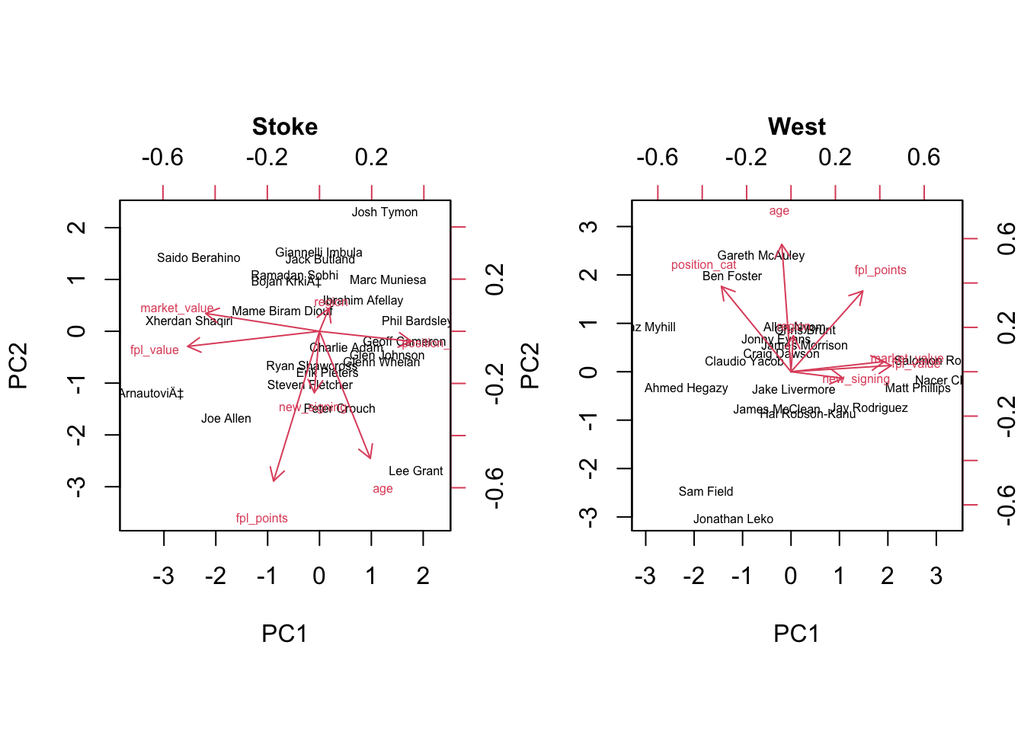

```r
biplot(West_pr, scale = 0, cex = 0.5, main = "West",cex.main=1)
```